# Hassoun et al_ctDNA in Testicular Cancer Clinical Analysis

library(swimplot) library(coxphf) library(grid) library(gtable) library(readr) library(mosaic) library(dplyr) library(survival) library(survminer) library(ggplot2) library(scales) library(coxphf) library(ggthemes) library(tidyverse) library(gtsummary) library(flextable) library(parameters) library(car) library(ComplexHeatmap) library(tidyverse) library(readxl) library(survival) library(janitor) library(rms) library(DT)

#ctDNA Detection rate by Stage and Window

```r
#Pre-Orchiectomy
rm(list=ls())
setwd("~/Downloads")
circ_data <- read.csv("CLIA Testicular_GL.csv")
circ_data <- circ_data[circ_data$ctDNA.available==TRUE,]
circ_data <- circ_data[circ_data$preSx.ctDNA.anytime!="",]
circ_data$preSx.ctDNA.anytime <- factor(circ_data$preSx.ctDNA.anytime, levels=c("NEGATIVE","POSITIVE"))
circ_data$Stage <- factor(circ_data$Stage, levels=c("I","II","III"))
circ_data <- subset(circ_data, preSx.ctDNA.anytime %in% c("NEGATIVE", "POSITIVE"))
positive_counts_by_stage <- aggregate(circ_data$preSx.ctDNA.anytime == "POSITIVE", by=list(circ_data$Stage), FUN=sum)
total_counts_by_stage <- aggregate(circ_data$preSx.ctDNA.anytime, by=list(circ_data$Stage), FUN=length)
combined_data <- data.frame(
  Stage = total_counts_by_stage$Group.1,
  Total_Count = total_counts_by_stage$x,
  Positive_Count = positive_counts_by_stage$x,
  Rate = (positive_counts_by_stage$x / total_counts_by_stage$x) * 100  # Convert to percentage
)
combined_data$Rate <- sprintf("%.2f%%", combined_data$Rate)
overall_total_count <- nrow(circ_data)
overall_positive_count <- nrow(circ_data[circ_data$preSx.ctDNA.anytime == "POSITIVE",])
overall_positivity_rate <- (overall_positive_count / overall_total_count) * 100  # Convert to percentage
overall_row <- data.frame(
  Stage = "Overall",
  Total_Count = overall_total_count,
  Positive_Count = overall_positive_count,
  Rate = sprintf("%.2f%%", overall_positivity_rate)
)
combined_data <- rbind(combined_data, overall_row)
print(combined_data)
```

| Stage | Total_Count | Positive_Count | Rate |
| --- | --- | --- | --- |
| I | 12 | 11 | 91.67% |
| II | 1 | 1 | 100.00% |
| III | 2 | 2 | 100.00% |
| Overall | 15 | 14 | 93.33% |

```r
#MRD Window
rm(list=ls())
setwd("~/Downloads")
circ_data <- read.csv("CLIA Testicular_GL.csv")
circ_data <- circ_data[circ_data$ctDNA.available==TRUE,]
circ_data <- circ_data[circ_data$ctDNA.MRD.Window!="",]
circ_data$ctDNA.MRD.Window <- factor(circ_data$ctDNA.MRD.Window, levels=c("NEGATIVE","POSITIVE"))
circ_data$Stage <- factor(circ_data$Stage, levels=c("I","II","III"))
circ_data <- subset(circ_data, ctDNA.MRD.Window %in% c("NEGATIVE", "POSITIVE"))
positive_counts_by_stage <- aggregate(circ_data$ctDNA.MRD.Window == "POSITIVE", by=list(circ_data$Stage), FUN=sum)
total_counts_by_stage <- aggregate(circ_data$ctDNA.MRD.Window, by=list(circ_data$Stage), FUN=length)
combined_data <- data.frame(
  Stage = total_counts_by_stage$Group.1,
  Total_Count = total_counts_by_stage$x,
  Positive_Count = positive_counts_by_stage$x,
  Rate = (positive_counts_by_stage$x / total_counts_by_stage$x) * 100  # Convert to percentage
)
combined_data$Rate <- sprintf("%.2f%%", combined_data$Rate)
overall_total_count <- nrow(circ_data)
overall_positive_count <- nrow(circ_data[circ_data$ctDNA.MRD.Window == "POSITIVE",])
overall_positivity_rate <- (overall_positive_count / overall_total_count) * 100  # Convert to percentage
overall_row <- data.frame(
  Stage = "Overall",
  Total_Count = overall_total_count,
  Positive_Count = overall_positive_count,
  Rate = sprintf("%.2f%%", overall_positivity_rate)
)
combined_data <- rbind(combined_data, overall_row)
print(combined_data)
```

| Stage | Total_Count | Positive_Count | Rate |
| --- | --- | --- | --- |
| I | 20 | 3 | 15.00% |
| II | 9 | 7 | 77.78% |
| III | 13 | 11 | 84.62% |
| Overall | 42 | 21 | 50.00% |

```r
#Surveillance Window
rm(list=ls())
setwd("~/Downloads")
circ_data <- read.csv("CLIA Testicular_GL.csv")
circ_data <- circ_data[circ_data$ctDNA.available==TRUE,]
circ_data <- circ_data[circ_data$ctDNA.surveillance!="",]
circ_data$ctDNA.MRD.Window <- factor(circ_data$ctDNA.surveillance, levels=c("NEGATIVE","POSITIVE"))
circ_data$Stage <- factor(circ_data$Stage, levels=c("I","II","III"))
circ_data <- subset(circ_data, ctDNA.surveillance %in% c("NEGATIVE", "POSITIVE"))
positive_counts_by_stage <- aggregate(circ_data$ctDNA.surveillance == "POSITIVE", by=list(circ_data$Stage), FUN=sum)
total_counts_by_stage <- aggregate(circ_data$ctDNA.surveillance, by=list(circ_data$Stage), FUN=length)
combined_data <- data.frame(
  Stage = total_counts_by_stage$Group.1,
  Total_Count = total_counts_by_stage$x,
  Positive_Count = positive_counts_by_stage$x,
  Rate = (positive_counts_by_stage$x / total_counts_by_stage$x) * 100  # Convert to percentage
)
combined_data$Rate <- sprintf("%.2f%%", combined_data$Rate)
overall_total_count <- nrow(circ_data)
overall_positive_count <- nrow(circ_data[circ_data$ctDNA.surveillance == "POSITIVE",])
overall_positivity_rate <- (overall_positive_count / overall_total_count) * 100  # Convert to percentage
overall_row <- data.frame(
  Stage = "Overall",
  Total_Count = overall_total_count,
  Positive_Count = overall_positive_count,
  Rate = sprintf("%.2f%%", overall_positivity_rate)
)
combined_data <- rbind(combined_data, overall_row)
print(combined_data)
```

| Stage | Total_Count | Positive_Count | Rate |
| --- | --- | --- | --- |
| I | 27 | 4 | 14.81% |
| II | 12 | 4 | 33.33% |
| III | 12 | 5 | 41.67% |
| Overall | 51 | 13 | 25.49% |

```r
#Anytime post-surgery
rm(list=ls())
setwd("~/Downloads")
circ_data <- read.csv("CLIA Testicular_GL.csv")
circ_data <- circ_data[circ_data$ctDNA.available==TRUE,]
circ_data <- circ_data[circ_data$postSx.ctDNA.anytime!="",]
circ_data$postSx.ctDNA.anytime <- factor(circ_data$postSx.ctDNA.anytime, levels=c("NEGATIVE","POSITIVE"))
circ_data$Stage <- factor(circ_data$Stage, levels=c("I","II","III"))
circ_data <- subset(circ_data, postSx.ctDNA.anytime %in% c("NEGATIVE", "POSITIVE"))
positive_counts_by_stage <- aggregate(circ_data$postSx.ctDNA.anytime == "POSITIVE", by=list(circ_data$Stage), FUN=sum)
total_counts_by_stage <- aggregate(circ_data$postSx.ctDNA.anytime, by=list(circ_data$Stage), FUN=length)
combined_data <- data.frame(
  Stage = total_counts_by_stage$Group.1,
  Total_Count = total_counts_by_stage$x,
  Positive_Count = positive_counts_by_stage$x,
  Rate = (positive_counts_by_stage$x / total_counts_by_stage$x) * 100  # Convert to percentage
)
combined_data$Rate <- sprintf("%.2f%%", combined_data$Rate)
overall_total_count <- nrow(circ_data)
overall_positive_count <- nrow(circ_data[circ_data$postSx.ctDNA.anytime == "POSITIVE",])
overall_positivity_rate <- (overall_positive_count / overall_total_count) * 100  # Convert to percentage
overall_row <- data.frame(
  Stage = "Overall",
  Total_Count = overall_total_count,
  Positive_Count = overall_positive_count,
  Rate = sprintf("%.2f%%", overall_positivity_rate)
)
combined_data <- rbind(combined_data, overall_row)
print(combined_data)
```

| Stage | Total_Count | Positive_Count | Rate |
| --- | --- | --- | --- |
| I | 29 | 5 | 17.24% |
| II | 17 | 12 | 70.59% |
| III | 26 | 21 | 80.77% |
| Overall | 72 | 38 | 52.78% |

#Demographics Table

```r
rm(list=ls())
setwd("~/Downloads")
circ_data <- read.csv("CLIA Testicular_GL.csv")
circ_data <- circ_data[circ_data$ctDNA.available==TRUE,]

circ_data_subset <- circ_data %>%
  select(
    Age,
    pT,
    Stage,
    Histology,
    Treatment,
    RPLND.Pathology,
    preSx.markers.anytime,
    Markers.postSx.anytime,
    PFS.Event,
    OS.Event,
    OS.months) %>%
  mutate(
    Age = as.numeric(Age),
    pT = factor(pT, levels = c("0","1", "2", "3", "X"), labels = c("pT0","pT1", "pT2", "pT3","pTX")),
    Stage = factor(Stage, levels = c("I", "II", "III")),
    Histology = factor(Histology, levels = c("Non seminoma", "Seminoma")),
    Treatment = factor(Treatment, levels = c("Surveillance", "Chemotherapy", "RPLND", "RPLND, Chemotherapy")),
    RPLND.Pathology = factor(RPLND.Pathology, levels = c("Negative", "Germ Cell/Teratoma")),
    preSx.markers.anytime = factor(preSx.markers.anytime, levels = c("NEGATIVE", "POSITIVE"), labels = c("Normal", "Elevated")),
    Markers.postSx.anytime = factor(Markers.postSx.anytime, levels = c("NEGATIVE", "POSITIVE"), labels = c("Normal", "Elevated")),
    PFS.Event = factor(PFS.Event, levels = c("FALSE", "TRUE"), labels = c("No Event", "Event")),
    OS.Event = factor(OS.Event, levels = c("FALSE", "TRUE"), labels = c("Alive", "Deceased")),
    OS.months = as.numeric(OS.months))
table1 <- circ_data_subset %>%
  tbl_summary(
    statistic = list(
      all_continuous() ~ "{median} ({p25} - {p75})",
      all_categorical() ~ "{n} ({p}%)"),
    label = list(
      Age ~ "Age",
      pT ~ "Pathological T Stage",
      Stage ~ "Overall Stage",
      Histology ~ "Histology",
      Treatment ~ "Post-surgery treatment",
      RPLND.Pathology ~ "RPLND Pathology",
      preSx.markers.anytime ~ "Serum Markers pre-op",
      Markers.postSx.anytime ~ "Serum Markers anytime post-op",
      PFS.Event ~ "Event During Follow-up",
      OS.Event ~ "Vital Status",
      OS.months ~ "Total Follow up (months)"),) %>%
  bold_labels()
table1
```

| **Characteristic** | **N = 74**<sup>1</sup> |
| --- | --- |
| Age | 34 (27 - 39) |
| Pathological T Stage |  |
| pT0 | 1 (1.4%) |
| pT1 | 39 (53%) |
| pT2 | 28 (38%) |
| pT3 | 3 (4.1%) |
| pTX | 3 (4.1%) |
| Overall Stage |  |
| I | 30 (41%) |
| II | 17 (23%) |
| III | 27 (36%) |
| Histology |  |
| Non seminoma | 51 (69%) |
| Seminoma | 23 (31%) |
| Post-surgery treatment |  |
| Surveillance | 17 (23%) |
| Chemotherapy | 30 (41%) |
| RPLND | 5 (6.8%) |
| RPLND, Chemotherapy | 22 (30%) |
| RPLND Pathology |  |
| Negative | 10 (37%) |
| Germ Cell/Teratoma | 17 (63%) |
| Unknown | 47 |
| Serum Markers pre-op |  |
| Normal | 19 (26%) |
| Elevated | 55 (74%) |
| Serum Markers anytime post-op |  |
| Normal | 30 (41%) |
| Elevated | 44 (59%) |
| Event During Follow-up |  |
| No Event | 39 (53%) |
| Event | 35 (47%) |
| Vital Status |  |
| Alive | 69 (93%) |
| Deceased | 5 (6.8%) |
| Total Follow up (months) | 17 (12 - 25) |

<sup>1</sup> Median (Q1 - Q3); n (%)

```r
fit1 <- as_flex_table(
  table1,
  include = everything(),
  return_calls = FALSE
)
fit1
```

| Characteristic | N = 741 |
| --- | --- |
| Age | 34 (27 - 39) |
| Pathological T Stage |  |
| pT0 | 1 (1.4%) |
| pT1 | 39 (53%) |
| pT2 | 28 (38%) |
| pT3 | 3 (4.1%) |
| pTX | 3 (4.1%) |
| Overall Stage |  |
| I | 30 (41%) |
| II | 17 (23%) |
| III | 27 (36%) |
| Histology |  |
| Non seminoma | 51 (69%) |
| Seminoma | 23 (31%) |
| Post-surgery treatment |  |
| Surveillance | 17 (23%) |
| Chemotherapy | 30 (41%) |
| RPLND | 5 (6.8%) |
| RPLND, Chemotherapy | 22 (30%) |
| RPLND Pathology |  |
| Negative | 10 (37%) |
| Germ Cell/Teratoma | 17 (63%) |
| Unknown | 47 |
| Serum Markers pre-op |  |
| Normal | 19 (26%) |
| Elevated | 55 (74%) |
| Serum Markers anytime post-op |  |
| Normal | 30 (41%) |
| Elevated | 44 (59%) |
| Event During Follow-up |  |
| No Event | 39 (53%) |
| Event | 35 (47%) |
| Vital Status |  |
| Alive | 69 (93%) |
| Deceased | 5 (6.8%) |
| Total Follow up (months) | 17 (12 - 25) |

1Median (Q1 - Q3); n (%)

```r
save_as_docx(fit1, path= "~/Downloads/table1.docx")
```

#Heatmap with Clinical & Genomics Factors

```r
rm(list=ls())
setwd("~/Downloads")
circ_data <- read.csv("CLIA Testicular_GL.csv")
circ_data <- circ_data[circ_data$ctDNA.available==TRUE,]
circ_data <- circ_data %>% arrange(Stage)
circ_datadf <- as.data.frame(circ_data)

ha <- HeatmapAnnotation(
  Stage = circ_data$Stage,
  Histology = circ_data$Histology,
  pT = circ_data$pT,
  Treatment = circ_data$Treatment,
  Platinum.Response = circ_data$Platinum.Response,
  PFS.Event = circ_data$PFS.Event,
  preSx.markers.anytime = circ_data$preSx.markers.anytime,
  Markers.MRD.Window = circ_data$Markers.MRD.Window,
  Markers.Surveillance = circ_data$Markers.Surveillance,
  Markers.post.ACT = circ_data$Markers.post.ACT,
  Markers.post.RPLND = circ_data$Markers.post.RPLND,
  Markers.postSx.anytime = circ_data$Markers.postSx.anytime,
  Markers.anytime = circ_data$Markers.anytime,
  preSx.ctDNA.anytime = circ_data$preSx.ctDNA.anytime,
  ctDNA.MRD.Window = circ_data$ctDNA.MRD.Window,
  ctDNA.surveillance = circ_data$ctDNA.surveillance,
  ctDNA.post.ACT = circ_data$ctDNA.post.ACT,
  ctDNA.post.RPLND = circ_data$ctDNA.post.RPLND,
  postSx.ctDNA.anytime = circ_data$postSx.ctDNA.anytime,
  ctDNA.anytime = circ_data$ctDNA.anytime,

  col = list(Stage = c("I" = "seagreen1", "II" = "orange", "III" = "purple"),
    Histology = c("Non seminoma" = "goldenrod" , "Seminoma" = "blue4"),
    pT = c("0" = "coral","1" = "coral", "2" ="darkgreen", "3" = "yellow3", "X" = "gray"),
    Treatment = c("Surveillance" = "lightblue", "Chemotherapy" = "orange2", "RPLND" ="khaki", "RPLND, Chemotherapy" = "brown2"),
    Platinum.Response = c("SD/PD" = "red3", "PR/CR" ="blue"),
    PFS.Event = c("TRUE" = "red3", "FALSE" ="blue"),
    preSx.markers.anytime = c("POSITIVE" = "red3", "NEGATIVE" ="blue"),
    Markers.MRD.Window = c("POSITIVE" = "red3", "NEGATIVE" ="blue"),
    Markers.Surveillance = c("POSITIVE" = "red3", "NEGATIVE" ="blue"),
    Markers.post.ACT = c("POSITIVE" = "red3", "NEGATIVE" ="blue"),
    Markers.post.RPLND = c("POSITIVE" = "red3", "NEGATIVE" ="blue"),
    Markers.postSx.anytime = c("POSITIVE" = "red3", "NEGATIVE" ="blue"),
    Markers.anytime = c("POSITIVE" = "red3", "NEGATIVE" ="blue"),
    preSx.ctDNA.anytime = c("POSITIVE" = "red3", "NEGATIVE" ="blue"),
    ctDNA.MRD.Window = c("POSITIVE" = "red3", "NEGATIVE" ="blue"),
    ctDNA.surveillance = c("POSITIVE" = "red3", "NEGATIVE" ="blue"),
    ctDNA.post.ACT = c("POSITIVE" = "red3", "NEGATIVE" ="blue"),
    ctDNA.post.RPLND = c("POSITIVE" = "red3", "NEGATIVE" ="blue"),
    postSx.ctDNA.anytime = c("POSITIVE" = "red3", "NEGATIVE" ="blue"),
    ctDNA.anytime = c("POSITIVE" = "red3", "NEGATIVE" ="blue")
)
)
ht <- Heatmap(matrix(nrow = 0, ncol = length(circ_data$Stage)),show_row_names = FALSE,cluster_rows = F,cluster_columns = FALSE, top_annotation = ha)
pdf("heatmap.pdf",width = 7, height = 7)
draw(ht, annotation_legend_side = "bottom")
dev.off()
```

#Overview plot

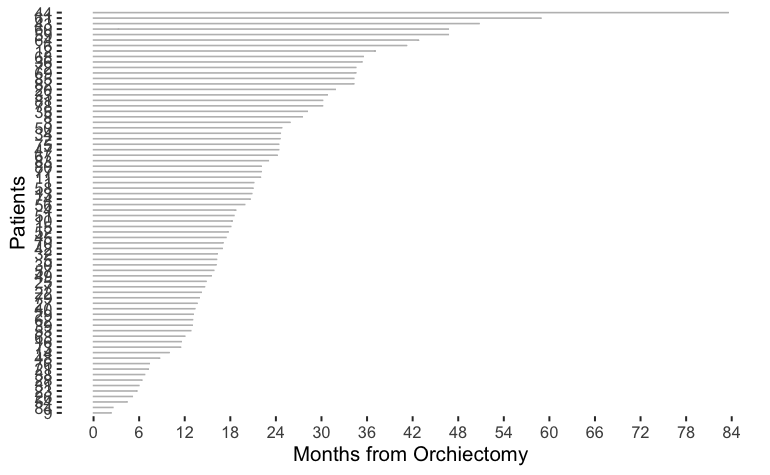

```r
library(swimplot)
library(ggplot2)
library(grid)
library(gtable)

#Overview plot
rm(list=ls())
setwd("~/Downloads")
clinstage<- read.csv("CLIA Testicular_OP.csv")
clinstage_df<- as.data.frame(clinstage)

oplot_stratify <-swimmer_plot(df=clinstage_df,
                              id='PatientName',
                              end='fu.diff.months',
                              #name_fill='Arm',
                              col="gray",
                              alpha=0.75,
                              width=.01,
                              base_size = 14,
                              )
oplot_stratify <- oplot_stratify + theme(panel.border = element_blank())
oplot_stratify <- oplot_stratify + scale_y_continuous(breaks = seq(0, 108, by = 6))
oplot_stratify <- oplot_stratify + labs(x ="Patients" , y="Months from Orchiectomy")
oplot_stratify
```

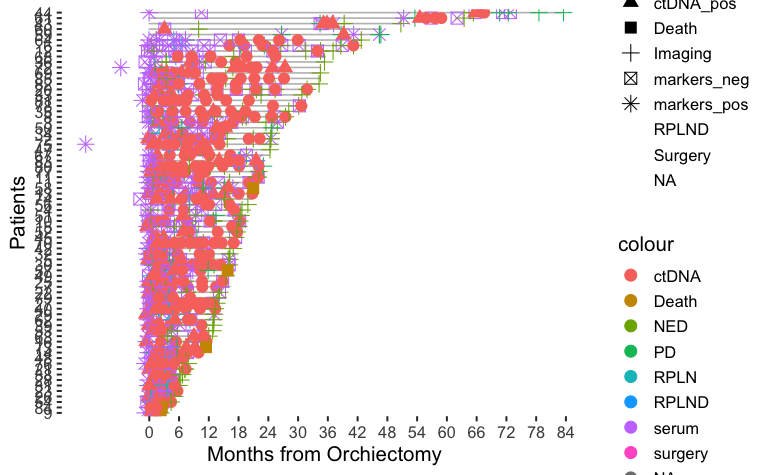

```r
#plot events
oplot_ev3 <- oplot_stratify + swimmer_points(df_points=clinstage_df,
                                             id='PatientName',
                                             time='date.diff.months',
                                             name_shape ='Event_type',
                                             name_col = 'Event',
                                             size=3.5,fill='black',
                                             #col='darkgreen'
)
oplot_ev3
```

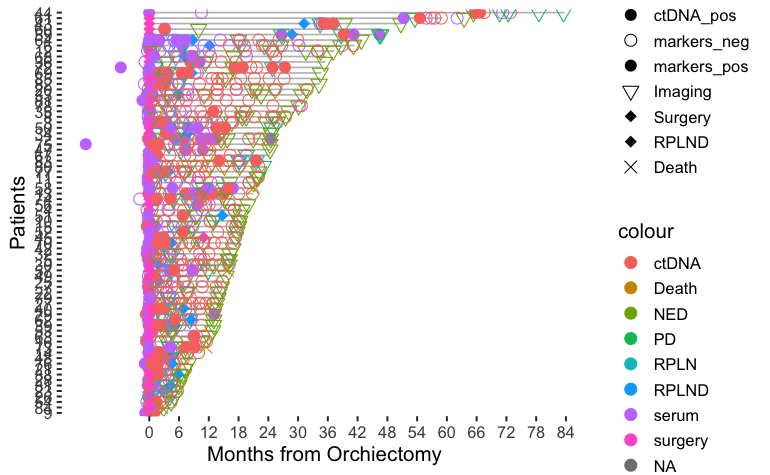

```r
#Shape customization to Event_type

oplot_ev3.1 <- oplot_ev3 + ggplot2::scale_shape_manual(name="Event_type",values=c(1,16,1,16,6,18,18,4),breaks=c('ctDNA_neg','ctDNA_pos','markers_neg','markers_pos','Imaging','Surgery','RPLND', 'Death'))

oplot_ev3.1
```

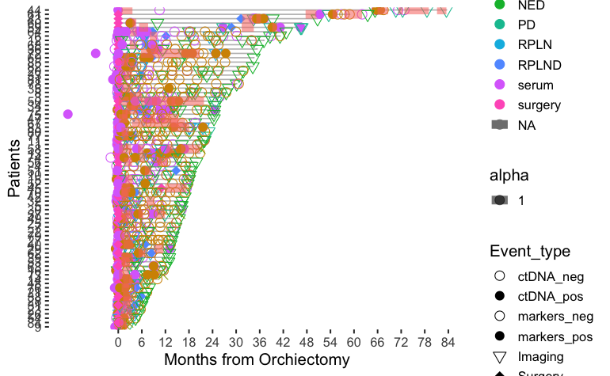

```r
#plot treatment
oplot_ev4 <- oplot_ev3.1 + swimmer_lines(df_lines=clinstage_df,
                                         id='PatientName',
                                         start='Tx_start.months',
                                         end='Tx_end.months',
                                         name_col='Tx_type',
                                         size=3.5,
                                         name_alpha = 1.0)
oplot_ev4 <- oplot_ev4 + guides(linetype = guide_legend(override.aes = list(size = 5, color = "black")))
oplot_ev4
```

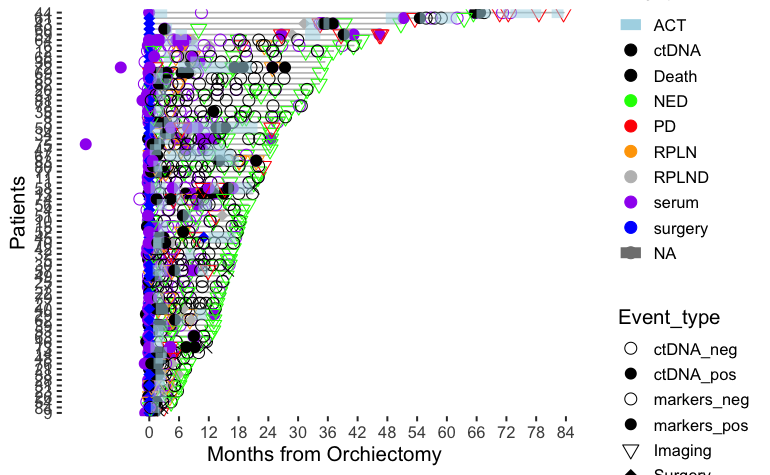

```r
#colour customization
oplot_ev4.2 <- oplot_ev4 + ggplot2::scale_color_manual(name="Event",values=c( "lightblue", "black", "black", "green", "red", "orange", "grey", "purple", "blue"))
oplot_ev4.2
```

#Overview plot Stratified by Stage

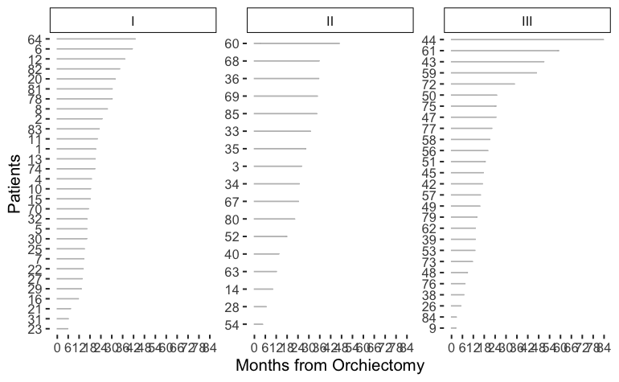

```r
library(swimplot)
library(ggplot2)
library(grid)
library(gtable)

#Overview plot
rm(list=ls())
setwd("~/Downloads")
clinstage<- read.csv("CLIA Testicular_OP.csv")
clinstage_df<- as.data.frame(clinstage)

oplot_stratify <-swimmer_plot(df=clinstage_df,
                              id='PatientName',
                              end='fu.diff.months',
                              #name_fill='Arm',
                              col="gray",
                              alpha=0.75,
                              width=.01,
                              base_size = 14,
                              stratify= c('Stage'))
oplot_stratify <- oplot_stratify + theme(panel.border = element_blank())
oplot_stratify <- oplot_stratify + scale_y_continuous(breaks = seq(0, 108, by = 6))
oplot_stratify <- oplot_stratify + labs(x ="Patients" , y="Months from Orchiectomy")
oplot_stratify
```

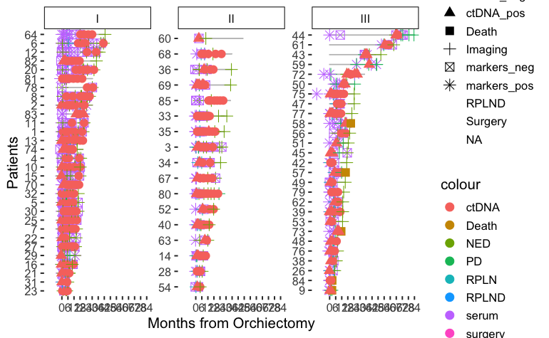

```r
#plot events
oplot_ev3 <- oplot_stratify + swimmer_points(df_points=clinstage_df,
                                             id='PatientName',
                                             time='date.diff.months',
                                             name_shape ='Event_type',
                                             name_col = 'Event',
                                             size=3.5,fill='black',
                                             #col='darkgreen'
)
oplot_ev3
```

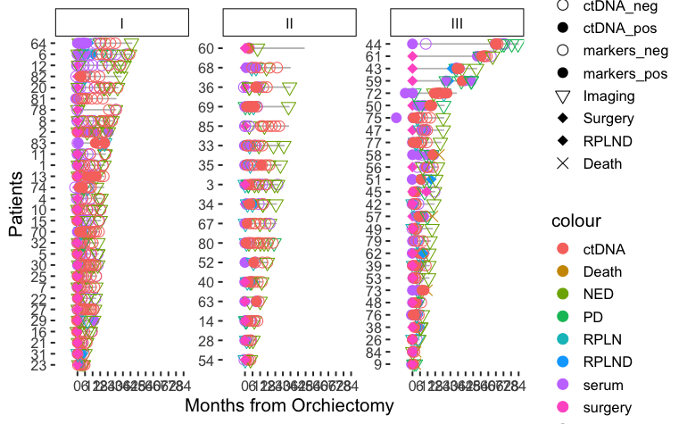

```r
#Shape customization to Event_type

oplot_ev3.1 <- oplot_ev3 + ggplot2::scale_shape_manual(name="Event_type",values=c(1,16,1,16,6,18,18,4),breaks=c('ctDNA_neg','ctDNA_pos','markers_neg','markers_pos','Imaging','Surgery','RPLND', 'Death'))

oplot_ev3.1
```

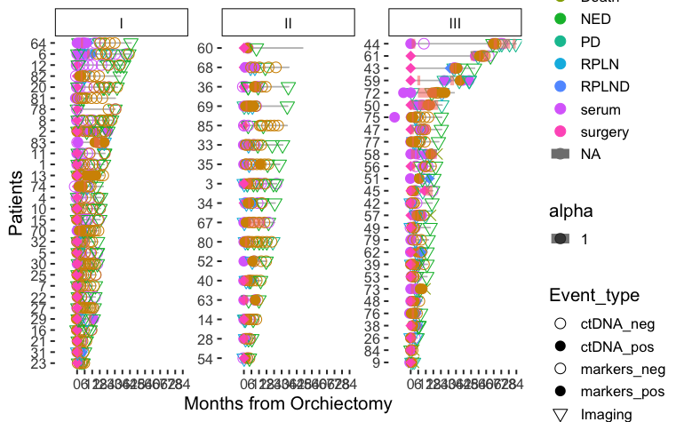

```r
#plot treatment
oplot_ev4 <- oplot_ev3.1 + swimmer_lines(df_lines=clinstage_df,
                                         id='PatientName',
                                         start='Tx_start.months',
                                         end='Tx_end.months',
                                         name_col='Tx_type',
                                         size=3.5,
                                         name_alpha = 1.0)
oplot_ev4 <- oplot_ev4 + guides(linetype = guide_legend(override.aes = list(size = 5, color = "black")))
oplot_ev4
```

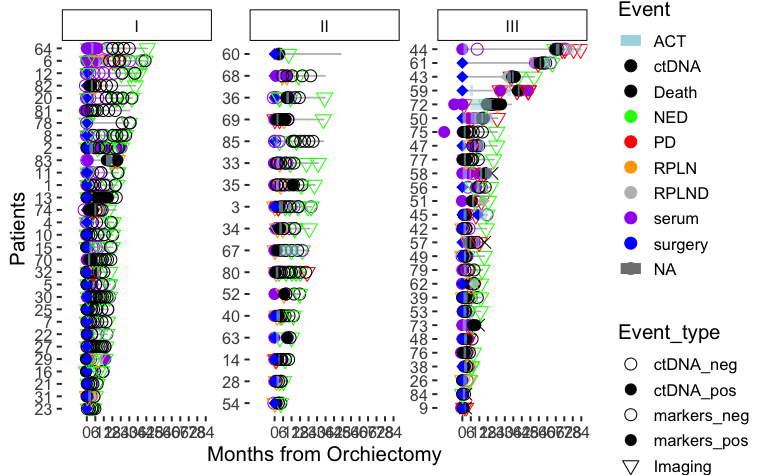

```r
#colour customization
oplot_ev4.2 <- oplot_ev4 + ggplot2::scale_color_manual(name="Event",values=c( "lightblue", "black", "black", "green", "red", "orange", "grey", "purple", "blue"))
oplot_ev4.2
```

#Sankey Plots for all pts with post-orchiectomy timepoint available

```r
##To run this commands, please visit: https://sankeymatic.com/build/
#No pre-orch [20] MRD positive #E67272
#No pre-orch [12] MRD negative #87EA86
#No pre-orch [27] no MRD timepoint #808080
#Pre-orch Positive [1] MRD positive #E67272
#Pre-orch Positive [8] MRD negative #87EA86
#Pre-orch Positive [5] no MRD timepoint #808080
#Pre-orch Negative [1] MRD negative #87EA86

#MRD positive [7] Surveillance positive #E67272
#MRD positive [7] Surveillance negative #87EA86
#MRD positive [7] no Surveillance timepoint #80808
#MRD negative [1] Surveillance positive #E67272
#MRD negative [18] Surveillance negative #87EA86
#MRD negative [2] no Surveillance timepoint #80808
#no MRD timepoint [5] Surveillance positive #E67272
#no MRD timepoint [13] Surveillance negative #87EA86
#no MRD timepoint [14] no Surveillance timepoint #808080

#Surveillance positive [13] Event #E67272
#Surveillance positive [0] No Event #87EA86
#Surveillance negative [5] Event #E67272
#Surveillance negative [33] No Event #87EA86
#no Surveillance timepoint [17] Event #E67272
#no Surveillance timepoint [6] No Event #87EA86
```

#EFS by ctDNA at the MRD Window

```r
rm(list=ls())
setwd("~/Downloads")
circ_data <- read.csv("CLIA Testicular_GL.csv")
circ_data <- circ_data[circ_data$ctDNA.available==TRUE,]
circ_data <- circ_data[circ_data$ctDNA.MRD.Window!="",]
circ_datadf <- as.data.frame(circ_data)

survfit(Surv(time = circ_data$PFS.months, event = circ_data$PFS.Event)~ctDNA.MRD.Window, data = circ_data)
```

```
Call: survfit(formula = Surv(time = circ_data$PFS.months, event = circ_data$PFS.Event) ~
    ctDNA.MRD.Window, data = circ_data)

                           n events median 0.95LCL 0.95UCL
ctDNA.MRD.Window=NEGATIVE 21      3     NA      NA      NA
ctDNA.MRD.Window=POSITIVE 21     13   5.36    4.07      NA
```

```r
event_summary <- circ_data %>%
  group_by(ctDNA.MRD.Window) %>%
  summarise(
    Total = n(),
    Events = sum(PFS.Event),
    Fraction = Events / n(),
    Percentage = (Events / n()) * 100
  )
print(event_summary)
```

| ctDNA.MRD.Window | Total | Events | Fraction | Percentage |
| --- | --- | --- | --- | --- |
| NEGATIVE | 21 | 3 | 0.1428571 | 14.28571 |
| POSITIVE | 21 | 13 | 0.6190476 | 61.90476 |

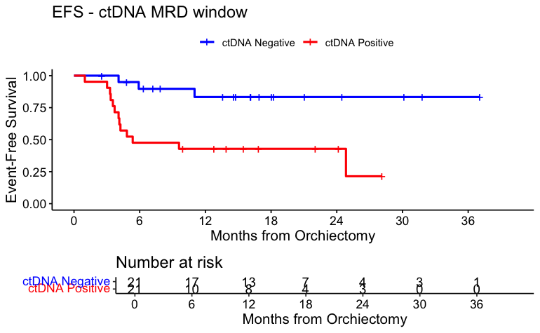

```r
surv_object <-Surv(time = circ_data$PFS.months, event = circ_data$PFS.Event)
KM_curve <- survfit(surv_object ~ ctDNA.MRD.Window, data = circ_data,conf.int=0.95,conf.type="log-log")
ggsurvplot(KM_curve, data = circ_data, pval = FALSE, conf.int = FALSE, risk.table = TRUE, break.time.by=6, palette=c("blue","red"), title="EFS - ctDNA MRD window", ylab= "Event-Free Survival", xlab="Months from Orchiectomy", legend.labs=c("ctDNA Negative", "ctDNA Positive"), legend.title="")
```

```r
summary(KM_curve, times= c(12, 24))
```

```
Call: survfit(formula = surv_object ~ ctDNA.MRD.Window, data = circ_data,
    conf.int = 0.95, conf.type = "log-log")

                ctDNA.MRD.Window=NEGATIVE
 time n.risk n.event survival std.err lower 95% CI upper 95% CI
   12     13       3    0.833  0.0889        0.563        0.944
   24      4       0    0.833  0.0889        0.563        0.944

                ctDNA.MRD.Window=POSITIVE
 time n.risk n.event survival std.err lower 95% CI upper 95% CI
   12      8      12    0.429   0.108        0.219        0.623
   24      3       0    0.429   0.108        0.219        0.623
```

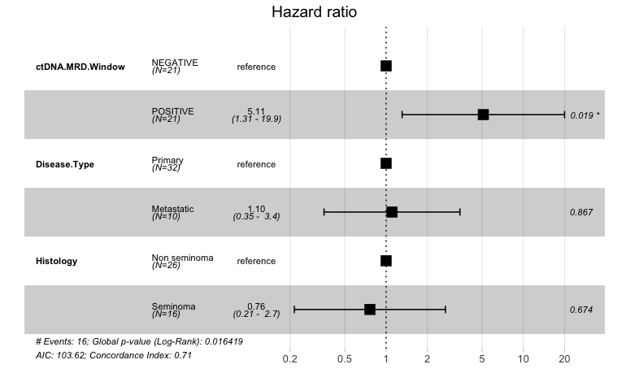

```r
circ_data$ctDNA.MRD.Window <- factor(circ_data$ctDNA.MRD.Window, levels=c("NEGATIVE","POSITIVE"))
circ_data$Disease.Type <- factor(circ_data$Disease.Type, levels = c("Primary", "Metastatic"))
circ_data$Histology <- factor(circ_data$Histology, levels = c("Non seminoma", "Seminoma"), labels = c("Non seminoma", "Seminoma"))
cox_fit <- coxph(surv_object ~ ctDNA.MRD.Window + Disease.Type + Histology, data=circ_data)
ggforest(cox_fit,data = circ_data)
```

```r
summary(cox_fit)
```

```
Call:
coxph(formula = surv_object ~ ctDNA.MRD.Window + Disease.Type +
    Histology, data = circ_data)

  n= 42, number of events= 16

                             coef exp(coef) se(coef)      z Pr(>|z|)
ctDNA.MRD.WindowPOSITIVE  1.63048   5.10634  0.69515  2.346    0.019 *
Disease.TypeMetastatic    0.09773   1.10267  0.58170  0.168    0.867
HistologySeminoma        -0.27236   0.76158  0.64651 -0.421    0.674
---
Signif. codes:  0 ‘***’ 0.001 ‘**’ 0.01 ‘*’ 0.05 ‘.’ 0.1 ‘ ’ 1

                         exp(coef) exp(-coef) lower .95 upper .95
ctDNA.MRD.WindowPOSITIVE    5.1063     0.1958    1.3074    19.945
Disease.TypeMetastatic      1.1027     0.9069    0.3526     3.448
HistologySeminoma           0.7616     1.3131    0.2145     2.704

Concordance= 0.707  (se = 0.053 )
Likelihood ratio test= 10.27  on 3 df,   p=0.02
Wald test            = 7.8  on 3 df,   p=0.05
Score (logrank) test = 9.96  on 3 df,   p=0.02
```

#EFS by STMs at the MRD Window

```r
rm(list=ls())
setwd("~/Downloads")
circ_data <- read.csv("CLIA Testicular_GL.csv")
circ_data <- circ_data[circ_data$ctDNA.available==TRUE,]
circ_data <- circ_data[circ_data$ctDNA.MRD.Window!="",]
circ_data <- circ_data[circ_data$Markers.MRD.Window!="",]
circ_datadf <- as.data.frame(circ_data)

survfit(Surv(time = circ_data$PFS.months, event = circ_data$PFS.Event)~Markers.MRD.Window, data = circ_data)
```

```
Call: survfit(formula = Surv(time = circ_data$PFS.months, event = circ_data$PFS.Event) ~
    Markers.MRD.Window, data = circ_data)

                             n events median 0.95LCL 0.95UCL
Markers.MRD.Window=NEGATIVE 16      3     NA      NA      NA
Markers.MRD.Window=POSITIVE 22     11   24.8    4.14      NA
```

```r
event_summary <- circ_data %>%
  group_by(Markers.MRD.Window) %>%
  summarise(
    Total = n(),
    Events = sum(PFS.Event),
    Fraction = Events / n(),
    Percentage = (Events / n()) * 100
  )
print(event_summary)
```

| Markers.MRD.Window | Total | Events | Fraction | Percentage |
| --- | --- | --- | --- | --- |
| NEGATIVE | 16 | 3 | 0.1875 | 18.75 |
| POSITIVE | 22 | 11 | 0.5000 | 50.00 |

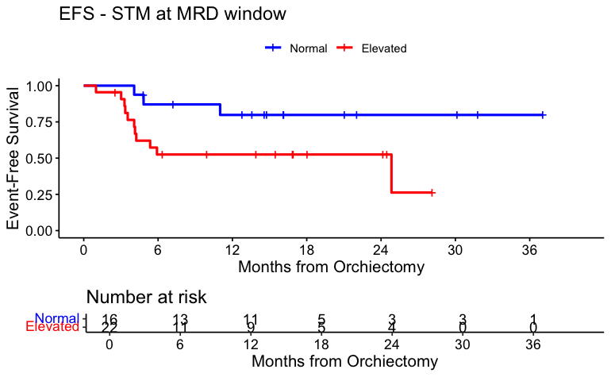

```r
surv_object <-Surv(time = circ_data$PFS.months, event = circ_data$PFS.Event)
KM_curve <- survfit(surv_object ~ Markers.MRD.Window, data = circ_data,conf.int=0.95,conf.type="log-log")
ggsurvplot(KM_curve, data = circ_data, pval = FALSE, conf.int = FALSE, risk.table = TRUE, break.time.by=6, palette=c("blue","red"), title="EFS - STM at MRD window", ylab= "Event-Free Survival", xlab="Months from Orchiectomy", legend.labs=c("Normal", "Elevated"), legend.title="")
```

```r
summary(KM_curve, times= c(12))
```

```
Call: survfit(formula = surv_object ~ Markers.MRD.Window, data = circ_data,
    conf.int = 0.95, conf.type = "log-log")

                Markers.MRD.Window=NEGATIVE
        time       n.risk      n.event     survival      std.err lower 95% CI upper 95% CI
      12.000       11.000        3.000        0.798        0.105        0.494        0.930

                Markers.MRD.Window=POSITIVE
        time       n.risk      n.event     survival      std.err lower 95% CI upper 95% CI
      12.000        9.000       10.000        0.525        0.109        0.298        0.710
```

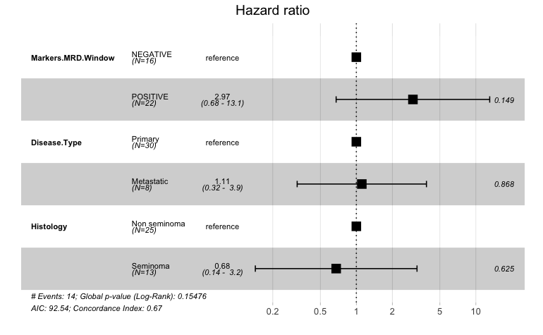

```r
circ_data$Markers.MRD.Window <- factor(circ_data$Markers.MRD.Window, levels=c("NEGATIVE","POSITIVE"))
circ_data$Disease.Type <- factor(circ_data$Disease.Type, levels = c("Primary", "Metastatic"))
circ_data$Histology <- factor(circ_data$Histology, levels = c("Non seminoma", "Seminoma"), labels = c("Non seminoma", "Seminoma"))
cox_fit <- coxph(surv_object ~ Markers.MRD.Window + Disease.Type + Histology, data=circ_data)
ggforest(cox_fit,data = circ_data)
```

```r
summary(cox_fit)
```

```
Call:
coxph(formula = surv_object ~ Markers.MRD.Window + Disease.Type +
    Histology, data = circ_data)

  n= 38, number of events= 14

                              coef exp(coef) se(coef)      z Pr(>|z|)
Markers.MRD.WindowPOSITIVE  1.0898    2.9738   0.7547  1.444    0.149
Disease.TypeMetastatic      0.1053    1.1110   0.6353  0.166    0.868
HistologySeminoma          -0.3885    0.6781   0.7945 -0.489    0.625

                           exp(coef) exp(-coef) lower .95 upper .95
Markers.MRD.WindowPOSITIVE    2.9738     0.3363    0.6775    13.054
Disease.TypeMetastatic        1.1110     0.9001    0.3198     3.859
HistologySeminoma             0.6781     1.4747    0.1429     3.218

Concordance= 0.669  (se = 0.061 )
Likelihood ratio test= 5.24  on 3 df,   p=0.2
Wald test            = 4.29  on 3 df,   p=0.2
Score (logrank) test = 4.91  on 3 df,   p=0.2
```

#EFS by ctDNA/STMs combined at the MRD Window

```r
rm(list=ls())
setwd("~/Downloads")
circ_data <- read.csv("CLIA Testicular_GL.csv")
circ_data <- circ_data[circ_data$ctDNA.available==TRUE,]
circ_data <- circ_data[circ_data$ctDNA.MRD.Window!="",]
circ_data <- circ_data[circ_data$Markers.MRD.Window!="",]
circ_datadf <- as.data.frame(circ_data)

circ_data$ctDNA.Dynamics <- NA #first we create the variable for the ctDNA & NAC combination, and we assign values
circ_data <- circ_data %>%
  mutate(ctDNA.Dynamics = case_when(
    ctDNA.MRD.Window == "NEGATIVE" & Markers.MRD.Window == "NEGATIVE" ~ "ctDNA/STMs (-)",
    (ctDNA.MRD.Window == "POSITIVE" & Markers.MRD.Window == "NEGATIVE") |
      (ctDNA.MRD.Window == "NEGATIVE" & Markers.MRD.Window == "POSITIVE") ~ "Discordant",
    ctDNA.MRD.Window == "POSITIVE" & Markers.MRD.Window == "POSITIVE" ~ "ctDNA/STMs (+)"
  ))

survfit(Surv(time = circ_data$PFS.months, event = circ_data$PFS.Event)~ctDNA.Dynamics, data = circ_data)
```

```
Call: survfit(formula = Surv(time = circ_data$PFS.months, event = circ_data$PFS.Event) ~
    ctDNA.Dynamics, data = circ_data)

                               n events median 0.95LCL 0.95UCL
ctDNA.Dynamics=ctDNA/STMs (-) 13      2     NA      NA      NA
ctDNA.Dynamics=ctDNA/STMs (+) 16     10    4.8    3.55      NA
ctDNA.Dynamics=Discordant      9      2     NA      NA      NA
```

```r
event_summary <- circ_data %>%
  group_by(ctDNA.Dynamics) %>%
  summarise(
    Total = n(),
    Events = sum(PFS.Event),
    Fraction = Events / n(),
    Percentage = (Events / n()) * 100
  )
print(event_summary)
```

| ctDNA.Dynamics | Total | Events | Fraction | Percentage |
| --- | --- | --- | --- | --- |
| Discordant | 9 | 2 | 0.2222222 | 22.22222 |
| ctDNA/STMs (+) | 16 | 10 | 0.6250000 | 62.50000 |
| ctDNA/STMs (-) | 13 | 2 | 0.1538462 | 15.38462 |

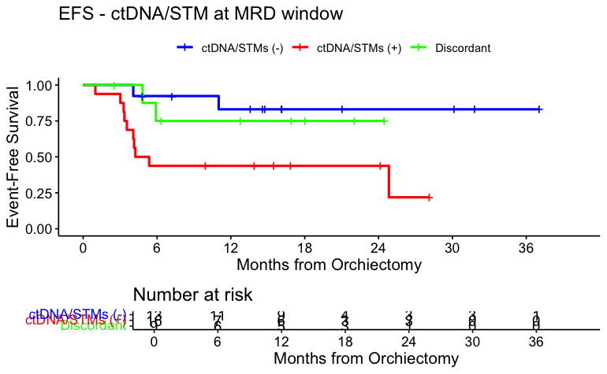

```r
surv_object <-Surv(time = circ_data$PFS.months, event = circ_data$PFS.Event)
KM_curve <- survfit(surv_object ~ ctDNA.Dynamics, data = circ_data,conf.int=0.95,conf.type="log-log")
ggsurvplot(KM_curve, data = circ_data, pval = FALSE, conf.int = FALSE, risk.table = TRUE, break.time.by=6, palette=c("blue","red","green"), title="EFS - ctDNA/STM at MRD window", ylab= "Event-Free Survival", xlab="Months from Orchiectomy", legend.labs=c("ctDNA/STMs (-)","ctDNA/STMs (+)","Discordant"), legend.title="")
```

```r
summary(KM_curve, times= c(12))
```

```
Call: survfit(formula = surv_object ~ ctDNA.Dynamics, data = circ_data,
    conf.int = 0.95, conf.type = "log-log")

                ctDNA.Dynamics=ctDNA/STMs (-)
        time       n.risk      n.event     survival      std.err lower 95% CI upper 95% CI
      12.000        9.000        2.000        0.831        0.110        0.472        0.955

                ctDNA.Dynamics=ctDNA/STMs (+)
        time       n.risk      n.event     survival      std.err lower 95% CI upper 95% CI
      12.000        6.000        9.000        0.438        0.124        0.198        0.656

                ctDNA.Dynamics=Discordant
        time       n.risk      n.event     survival      std.err lower 95% CI upper 95% CI
      12.000        5.000        2.000        0.750        0.153        0.315        0.931
```

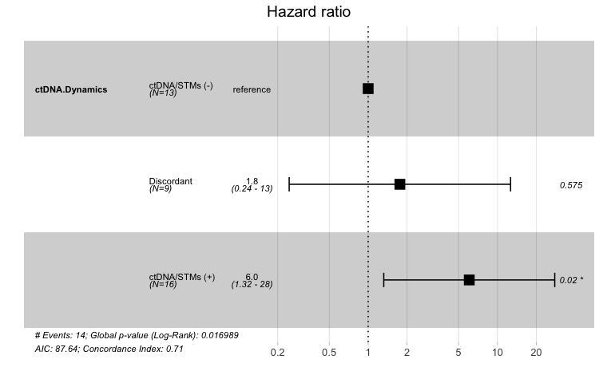

```r
circ_data$ctDNA.Dynamics <- factor(circ_data$ctDNA.Dynamics, levels=c("ctDNA/STMs (-)","Discordant","ctDNA/STMs (+)"))
circ_data$Disease.Type <- factor(circ_data$Disease.Type, levels = c("Primary", "Metastatic"))
circ_data$Histology <- factor(circ_data$Histology, levels = c("Non seminoma", "Seminoma"), labels = c("Non seminoma", "Seminoma"))
cox_fit <- coxph(surv_object ~ ctDNA.Dynamics, data=circ_data)
ggforest(cox_fit,data = circ_data)
```

```r
summary(cox_fit)
```

```
Call:
coxph(formula = surv_object ~ ctDNA.Dynamics, data = circ_data)

  n= 38, number of events= 14

                               coef exp(coef) se(coef)     z Pr(>|z|)
ctDNA.DynamicsDiscordant     0.5646    1.7588   1.0057 0.561   0.5745
ctDNA.DynamicsctDNA/STMs (+) 1.7998    6.0483   0.7767 2.317   0.0205 *
---
Signif. codes:  0 ‘***’ 0.001 ‘**’ 0.01 ‘*’ 0.05 ‘.’ 0.1 ‘ ’ 1

                             exp(coef) exp(-coef) lower .95 upper .95
ctDNA.DynamicsDiscordant         1.759     0.5686     0.245     12.63
ctDNA.DynamicsctDNA/STMs (+)     6.048     0.1653     1.320     27.72

Concordance= 0.713  (se = 0.06 )
Likelihood ratio test= 8.15  on 2 df,   p=0.02
Wald test            = 6.84  on 2 df,   p=0.03
Score (logrank) test = 8.47  on 2 df,   p=0.01
```

#Median MTM/mL at the MRD Window and by PFS status

```r
rm(list=ls())
setwd("~/Downloads")
circ_data <- read.csv("CLIA Testicular_GL.csv")
circ_data <- circ_data[circ_data$ctDNA.available == TRUE, ]
circ_data <- circ_data[circ_data$ctDNA.MRD.Window != "", ]

# 1. Median and range of ctDNA.MRD.MTM for POSITIVE MRD Window
positive_data <- circ_data %>% filter(ctDNA.MRD.Window == "POSITIVE")
median_positive <- median(positive_data$ctDNA.MRD.MTM, na.rm = TRUE)
range_positive <- range(positive_data$ctDNA.MRD.MTM, na.rm = TRUE)
cat("Median ctDNA.MRD.MTM in MRD-Positive group:", median_positive, "\n")
```

```
Median ctDNA.MRD.MTM in MRD-Positive group: 50.53
```

```r
cat("Range of ctDNA.MRD.MTM in MRD-Positive group:", range_positive[1], "-", range_positive[2], "\n\n")
```

```
Range of ctDNA.MRD.MTM in MRD-Positive group: 3.15 - 756.65
```

#EFS by ctDNA at the Surveillance Window

```r
rm(list=ls())
setwd("~/Downloads")
circ_data <- read.csv("CLIA Testicular_GL.csv")
circ_data <- circ_data[circ_data$ctDNA.available==TRUE,]
circ_data <- circ_data[circ_data$ctDNA.surveillance!="",]
circ_datadf <- as.data.frame(circ_data)

survfit(Surv(time = circ_data$PFS.months, event = circ_data$PFS.Event)~ctDNA.surveillance, data = circ_data)
```

```
Call: survfit(formula = Surv(time = circ_data$PFS.months, event = circ_data$PFS.Event) ~
    ctDNA.surveillance, data = circ_data)

                             n events median 0.95LCL 0.95UCL
ctDNA.surveillance=NEGATIVE 38      5     NA      NA      NA
ctDNA.surveillance=POSITIVE 13     13   4.83    3.35      NA
```

```r
event_summary <- circ_data %>%
  group_by(ctDNA.surveillance) %>%
  summarise(
    Total = n(),
    Events = sum(PFS.Event),
    Fraction = Events / n(),
    Percentage = (Events / n()) * 100
  )
print(event_summary)
```

| ctDNA.surveillance | Total | Events | Fraction | Percentage |
| --- | --- | --- | --- | --- |
| NEGATIVE | 38 | 5 | 0.1315789 | 13.15789 |
| POSITIVE | 13 | 13 | 1.0000000 | 100.00000 |

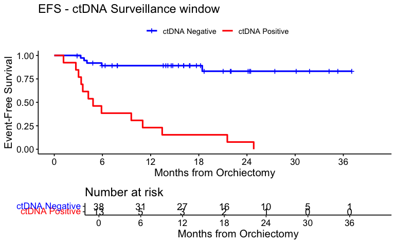

```r
surv_object <-Surv(time = circ_data$PFS.months, event = circ_data$PFS.Event)
KM_curve <- survfit(surv_object ~ ctDNA.surveillance, data = circ_data,conf.int=0.95,conf.type="log-log")
ggsurvplot(KM_curve, data = circ_data, pval = FALSE, conf.int = FALSE, risk.table = TRUE, break.time.by=6, palette=c("blue","red"), title="EFS - ctDNA Surveillance window", ylab= "Event-Free Survival", xlab="Months from Orchiectomy", legend.labs=c("ctDNA Negative", "ctDNA Positive"), legend.title="")
```

```r
summary(KM_curve, times= c(12))
```

```
Call: survfit(formula = surv_object ~ ctDNA.surveillance, data = circ_data,
    conf.int = 0.95, conf.type = "log-log")

                ctDNA.surveillance=NEGATIVE
        time       n.risk      n.event     survival      std.err lower 95% CI upper 95% CI
     12.0000      27.0000       4.0000       0.8911       0.0514       0.7352       0.9577

                ctDNA.surveillance=POSITIVE
        time       n.risk      n.event     survival      std.err lower 95% CI upper 95% CI
     12.0000       3.0000      10.0000       0.2308       0.1169       0.0558       0.4746
```

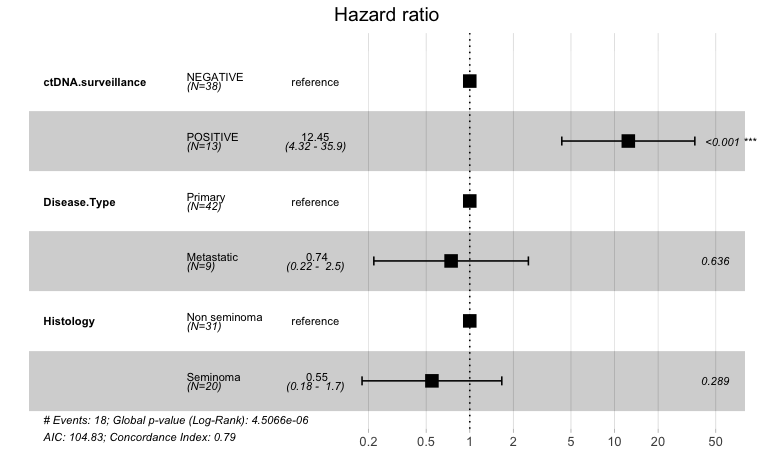

```r
circ_data$ctDNA.surveillance <- factor(circ_data$ctDNA.surveillance, levels=c("NEGATIVE","POSITIVE"))
circ_data$Disease.Type <- factor(circ_data$Disease.Type, levels = c("Primary", "Metastatic"))
circ_data$Histology <- factor(circ_data$Histology, levels = c("Non seminoma", "Seminoma"), labels = c("Non seminoma", "Seminoma"))
cox_fit <- coxph(surv_object ~ ctDNA.surveillance + Disease.Type + Histology, data=circ_data)
ggforest(cox_fit,data = circ_data)
```

```r
summary(cox_fit)
```

```
Call:
coxph(formula = surv_object ~ ctDNA.surveillance + Disease.Type +
    Histology, data = circ_data)

  n= 51, number of events= 18

                              coef exp(coef) se(coef)      z Pr(>|z|)
ctDNA.surveillancePOSITIVE  2.5216   12.4485   0.5397  4.672 2.98e-06 ***
Disease.TypeMetastatic     -0.2967    0.7433   0.6270 -0.473    0.636
HistologySeminoma          -0.6017    0.5479   0.5670 -1.061    0.289
---
Signif. codes:  0 ‘***’ 0.001 ‘**’ 0.01 ‘*’ 0.05 ‘.’ 0.1 ‘ ’ 1

                           exp(coef) exp(-coef) lower .95 upper .95
ctDNA.surveillancePOSITIVE   12.4485    0.08033    4.3222    35.854
Disease.TypeMetastatic        0.7433    1.34535    0.2175     2.540
HistologySeminoma             0.5479    1.82529    0.1803     1.665

Concordance= 0.793  (se = 0.069 )
Likelihood ratio test= 27.55  on 3 df,   p=5e-06
Wald test            = 23.95  on 3 df,   p=3e-05
Score (logrank) test = 38.6  on 3 df,   p=2e-08
```

#EFS by Serum Markers at the Surveillance Window

```r
rm(list=ls())
setwd("~/Downloads")
circ_data <- read.csv("CLIA Testicular_GL.csv")
circ_data <- circ_data[circ_data$ctDNA.available==TRUE,]
circ_data <- circ_data[circ_data$Markers.Surveillance!="",]
circ_datadf <- as.data.frame(circ_data)

survfit(Surv(time = circ_data$PFS.months, event = circ_data$PFS.Event)~Markers.Surveillance, data = circ_data)
```

```
Call: survfit(formula = Surv(time = circ_data$PFS.months, event = circ_data$PFS.Event) ~
    Markers.Surveillance, data = circ_data)

                               n events median 0.95LCL 0.95UCL
Markers.Surveillance=NEGATIVE 48     15   65.3      NA      NA
Markers.Surveillance=POSITIVE 14     11   18.4    7.82      NA
```

```r
event_summary <- circ_data %>%
  group_by(Markers.Surveillance) %>%
  summarise(
    Total = n(),
    Events = sum(PFS.Event),
    Fraction = Events / n(),
    Percentage = (Events / n()) * 100
  )
print(event_summary)
```

| Markers.Surveillance | Total | Events | Fraction | Percentage |
| --- | --- | --- | --- | --- |
| NEGATIVE | 48 | 15 | 0.3125000 | 31.25000 |
| POSITIVE | 14 | 11 | 0.7857143 | 78.57143 |

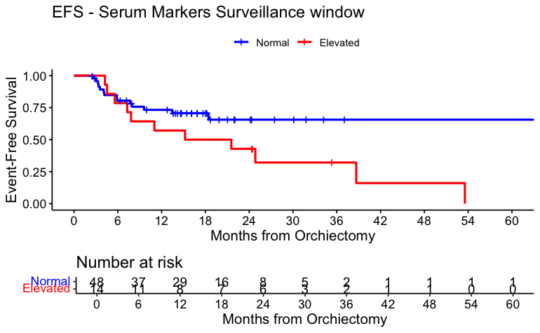

```r
surv_object <-Surv(time = circ_data$PFS.months, event = circ_data$PFS.Event)
KM_curve <- survfit(surv_object ~ Markers.Surveillance, data = circ_data,conf.int=0.95,conf.type="log-log")
ggsurvplot(KM_curve, data = circ_data, pval = FALSE, conf.int = FALSE, risk.table = TRUE, break.time.by=6, palette=c("blue","red"), title="EFS - Serum Markers Surveillance window", ylab= "Event-Free Survival", xlab="Months from Orchiectomy", legend.labs=c("Normal", "Elevated"), legend.title="")
```

```r
summary(KM_curve, times= c(12))
```

```
Call: survfit(formula = surv_object ~ Markers.Surveillance, data = circ_data,
    conf.int = 0.95, conf.type = "log-log")

                Markers.Surveillance=NEGATIVE
        time       n.risk      n.event     survival      std.err lower 95% CI upper 95% CI
     12.0000      29.0000      12.0000       0.7329       0.0663       0.5770       0.8389

                Markers.Surveillance=POSITIVE
        time       n.risk      n.event     survival      std.err lower 95% CI upper 95% CI
      12.000        8.000        6.000        0.571        0.132        0.284        0.780
```

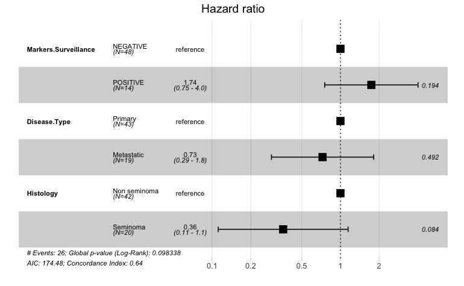

```r
circ_data$Markers.Surveillance <- factor(circ_data$Markers.Surveillance, levels=c("NEGATIVE","POSITIVE"))
circ_data$Disease.Type <- factor(circ_data$Disease.Type, levels = c("Primary", "Metastatic"))
circ_data$Histology <- factor(circ_data$Histology, levels = c("Non seminoma", "Seminoma"), labels = c("Non seminoma", "Seminoma"))
cox_fit <- coxph(surv_object ~ Markers.Surveillance + Disease.Type + Histology, data=circ_data)
ggforest(cox_fit,data = circ_data)
```

```r
summary(cox_fit)
```

```
Call:
coxph(formula = surv_object ~ Markers.Surveillance + Disease.Type +
    Histology, data = circ_data)

  n= 62, number of events= 26

                                coef exp(coef) se(coef)      z Pr(>|z|)
Markers.SurveillancePOSITIVE  0.5545    1.7410   0.4271  1.298   0.1942
Disease.TypeMetastatic       -0.3215    0.7251   0.4678 -0.687   0.4919
HistologySeminoma            -1.0279    0.3578   0.5944 -1.729   0.0838 .
---
Signif. codes:  0 ‘***’ 0.001 ‘**’ 0.01 ‘*’ 0.05 ‘.’ 0.1 ‘ ’ 1

                             exp(coef) exp(-coef) lower .95 upper .95
Markers.SurveillancePOSITIVE    1.7410     0.5744    0.7538     4.021
Disease.TypeMetastatic          0.7251     1.3792    0.2899     1.814
HistologySeminoma               0.3578     2.7952    0.1116     1.147

Concordance= 0.638  (se = 0.05 )
Likelihood ratio test= 6.29  on 3 df,   p=0.1
Wald test            = 5.69  on 3 df,   p=0.1
Score (logrank) test = 6.19  on 3 df,   p=0.1
```

#EFS by ctDNA/STms combined at the Surveillance Window

```r
rm(list=ls())
setwd("~/Downloads")
circ_data <- read.csv("CLIA Testicular_GL.csv")
circ_data <- circ_data[circ_data$ctDNA.available==TRUE,]
circ_data <- circ_data[circ_data$ctDNA.surveillance!="",]
circ_data <- circ_data[circ_data$Markers.Surveillance!="",]
circ_datadf <- as.data.frame(circ_data)

circ_data$ctDNA.Dynamics <- NA #first we create the variable for the ctDNA & NAC combination, and we assign values
circ_data <- circ_data %>%
  mutate(ctDNA.Dynamics = case_when(
    ctDNA.surveillance == "NEGATIVE" & Markers.Surveillance == "NEGATIVE" ~ "ctDNA/STMs (-)",
    (ctDNA.surveillance == "POSITIVE" & Markers.Surveillance == "NEGATIVE") |
      (ctDNA.surveillance == "NEGATIVE" & Markers.Surveillance == "POSITIVE") ~ "Discordant",
    ctDNA.surveillance == "POSITIVE" & Markers.Surveillance == "POSITIVE" ~ "ctDNA/STMs (+)"
  ))

survfit(Surv(time = circ_data$PFS.months, event = circ_data$PFS.Event)~ctDNA.Dynamics, data = circ_data)
```

```
Call: survfit(formula = Surv(time = circ_data$PFS.months, event = circ_data$PFS.Event) ~
    ctDNA.Dynamics, data = circ_data)

                               n events median 0.95LCL 0.95UCL
ctDNA.Dynamics=ctDNA/STMs (-) 32      4     NA      NA      NA
ctDNA.Dynamics=ctDNA/STMs (+)  4      4  16.28    4.24      NA
ctDNA.Dynamics=Discordant     10      7   7.73    3.35      NA
```

```r
event_summary <- circ_data %>%
  group_by(ctDNA.Dynamics) %>%
  summarise(
    Total = n(),
    Events = sum(PFS.Event),
    Fraction = Events / n(),
    Percentage = (Events / n()) * 100
  )
print(event_summary)
```

| ctDNA.Dynamics | Total | Events | Fraction | Percentage |
| --- | --- | --- | --- | --- |
| Discordant | 10 | 7 | 0.700 | 70.0 |
| ctDNA/STMs (+) | 4 | 4 | 1.000 | 100.0 |
| ctDNA/STMs (-) | 32 | 4 | 0.125 | 12.5 |

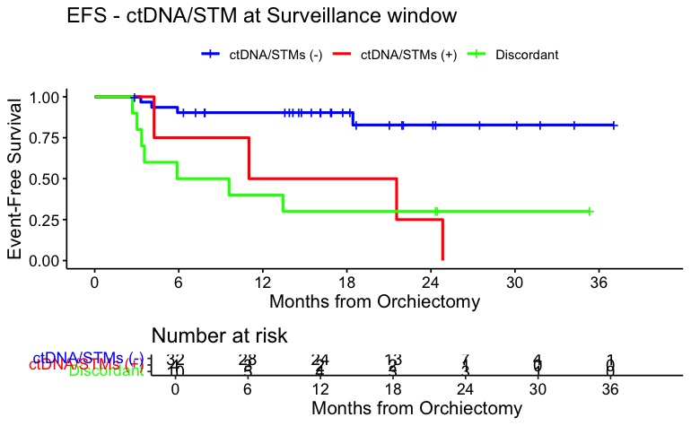

```r
surv_object <-Surv(time = circ_data$PFS.months, event = circ_data$PFS.Event)
KM_curve <- survfit(surv_object ~ ctDNA.Dynamics, data = circ_data,conf.int=0.95,conf.type="log-log")
ggsurvplot(KM_curve, data = circ_data, pval = FALSE, conf.int = FALSE, risk.table = TRUE, break.time.by=6, palette=c("blue","red","green"), title="EFS - ctDNA/STM at Surveillance window", ylab= "Event-Free Survival", xlab="Months from Orchiectomy", legend.labs=c("ctDNA/STMs (-)","ctDNA/STMs (+)","Discordant"), legend.title="")
```

```r
summary(KM_curve, times= c(12))
```

```
Call: survfit(formula = surv_object ~ ctDNA.Dynamics, data = circ_data,
    conf.int = 0.95, conf.type = "log-log")

                ctDNA.Dynamics=ctDNA/STMs (-)
        time       n.risk      n.event     survival      std.err lower 95% CI upper 95% CI
     12.0000      24.0000       3.0000       0.9032       0.0531       0.7293       0.9677

                ctDNA.Dynamics=ctDNA/STMs (+)
        time       n.risk      n.event     survival      std.err lower 95% CI upper 95% CI
     12.0000       2.0000       2.0000       0.5000       0.2500       0.0578       0.8449

                ctDNA.Dynamics=Discordant
        time       n.risk      n.event     survival      std.err lower 95% CI upper 95% CI
      12.000        4.000        6.000        0.400        0.155        0.123        0.670
```

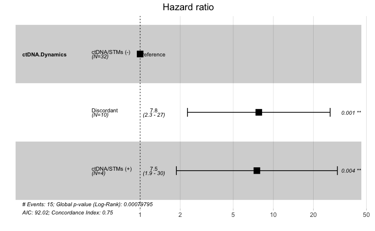

```r
circ_data$ctDNA.Dynamics <- factor(circ_data$ctDNA.Dynamics, levels=c("ctDNA/STMs (-)","Discordant","ctDNA/STMs (+)"))
circ_data$Disease.Type <- factor(circ_data$Disease.Type, levels = c("Primary", "Metastatic"))
circ_data$Histology <- factor(circ_data$Histology, levels = c("Non seminoma", "Seminoma"), labels = c("Non seminoma", "Seminoma"))
cox_fit <- coxph(surv_object ~ ctDNA.Dynamics, data=circ_data)
ggforest(cox_fit,data = circ_data)
```

```r
summary(cox_fit)
```

```
Call:
coxph(formula = surv_object ~ ctDNA.Dynamics, data = circ_data)

  n= 46, number of events= 15

                               coef exp(coef) se(coef)     z Pr(>|z|)
ctDNA.DynamicsDiscordant     2.0516    7.7803   0.6292 3.261  0.00111 **
ctDNA.DynamicsctDNA/STMs (+) 2.0185    7.5272   0.7099 2.844  0.00446 **
---
Signif. codes:  0 ‘***’ 0.001 ‘**’ 0.01 ‘*’ 0.05 ‘.’ 0.1 ‘ ’ 1

                             exp(coef) exp(-coef) lower .95 upper .95
ctDNA.DynamicsDiscordant         7.780     0.1285     2.267     26.70
ctDNA.DynamicsctDNA/STMs (+)     7.527     0.1329     1.872     30.26

Concordance= 0.749  (se = 0.065 )
Likelihood ratio test= 14.27  on 2 df,   p=8e-04
Wald test            = 12.11  on 2 df,   p=0.002
Score (logrank) test = 16.8  on 2 df,   p=2e-04
```

#EFS by ctDNA at post-RPLND - Stage II

```r
rm(list=ls())
setwd("~/Downloads")
circ_data <- read.csv("CLIA Testicular_GL.csv")
circ_data <- circ_data[circ_data$ctDNA.available==TRUE,]
circ_data <- circ_data[circ_data$RPLND==TRUE,]
circ_data <- circ_data[circ_data$Stage=="II",]
circ_data <- circ_data[circ_data$ctDNA.post.RPLND!="",]
circ_datadf <- as.data.frame(circ_data)

survfit(Surv(time = circ_data$PFS.months, event = circ_data$PFS.Event)~ctDNA.post.RPLND, data = circ_data)
```

```
Call: survfit(formula = Surv(time = circ_data$PFS.months, event = circ_data$PFS.Event) ~
    ctDNA.post.RPLND, data = circ_data)

                          n events median 0.95LCL 0.95UCL
ctDNA.post.RPLND=NEGATIVE 4      2   7.69    5.91      NA
ctDNA.post.RPLND=POSITIVE 2      2   1.92    1.15      NA
```

```r
event_summary <- circ_data %>%
  group_by(ctDNA.post.RPLND) %>%
  summarise(
    Total = n(),
    Events = sum(PFS.Event),
    Fraction = Events / n(),
    Percentage = (Events / n()) * 100
  )
print(event_summary)
```

| ctDNA.post.RPLND | Total | Events | Fraction | Percentage |
| --- | --- | --- | --- | --- |
| NEGATIVE | 4 | 2 | 0.5 | 50 |
| POSITIVE | 2 | 2 | 1.0 | 100 |

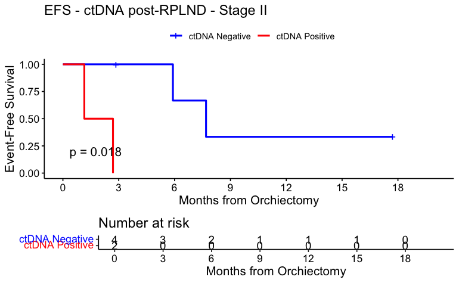

```r
surv_object <-Surv(time = circ_data$PFS.months, event = circ_data$PFS.Event)
KM_curve <- survfit(surv_object ~ ctDNA.post.RPLND, data = circ_data,conf.int=0.95,conf.type="log-log")
ggsurvplot(KM_curve, data = circ_data, pval = TRUE, conf.int = FALSE, risk.table = TRUE, break.time.by=3, palette=c("blue","red"), title="EFS - ctDNA post-RPLND - Stage II", ylab= "Event-Free Survival", xlab="Months from Orchiectomy", legend.labs=c("ctDNA Negative", "ctDNA Positive"), legend.title="")
```

```r
summary(KM_curve, times= c(0, 12))
```

```
Call: survfit(formula = surv_object ~ ctDNA.post.RPLND, data = circ_data,
    conf.int = 0.95, conf.type = "log-log")

                ctDNA.post.RPLND=NEGATIVE
 time n.risk n.event survival std.err lower 95% CI upper 95% CI
    0      4       0    1.000   0.000      1.00000        1.000
   12      1       2    0.333   0.272      0.00896        0.774

                ctDNA.post.RPLND=POSITIVE
        time       n.risk      n.event     survival      std.err lower 95% CI upper 95% CI
           0            2            0            1            0            1            1
```

```r
circ_data$ctDNA.post.RPLND <- factor(circ_data$ctDNA.post.RPLND, levels=c("NEGATIVE","POSITIVE"))
cox_fit <- coxphf(surv_object ~ ctDNA.post.RPLND, data=circ_data)
summary(cox_fit)
```

```
coxphf(formula = surv_object ~ ctDNA.post.RPLND, data = circ_data)

Model fitted by Penalized ML
Confidence intervals and p-values by Profile Likelihood

                             coef se(coef) exp(coef) lower 0.95 upper 0.95   Chisq          p
ctDNA.post.RPLNDPOSITIVE 2.715398 1.929072  15.11062   1.165602   2114.922 4.34548 0.03710731

Likelihood ratio test=4.34548 on 1 df, p=0.03710731, n=6
Wald test = 1.981391 on 1 df, p = 0.159244

Covariance-Matrix:
                         ctDNA.post.RPLNDPOSITIVE
ctDNA.post.RPLNDPOSITIVE                 3.721317
```

#EFS by ctDNA at post-ACT - Stage II/III

```r
rm(list=ls())
setwd("~/Downloads")
circ_data <- read.csv("CLIA Testicular_GL.csv")
circ_data <- circ_data[circ_data$ctDNA.available==TRUE,]
circ_data <- circ_data[circ_data$ACT==TRUE,]
circ_data <- circ_data[circ_data$Stage!="I",]
circ_data <- circ_data[circ_data$ctDNA.surveillance!="",]
circ_datadf <- as.data.frame(circ_data)

survfit(Surv(time = circ_data$PFS.months, event = circ_data$PFS.Event)~ctDNA.surveillance, data = circ_data)
```

```
Call: survfit(formula = Surv(time = circ_data$PFS.months, event = circ_data$PFS.Event) ~
    ctDNA.surveillance, data = circ_data)

                             n events median 0.95LCL 0.95UCL
ctDNA.surveillance=NEGATIVE 13      3     NA      NA      NA
ctDNA.surveillance=POSITIVE  9      9   4.24    3.35      NA
```

```r
event_summary <- circ_data %>%
  group_by(ctDNA.surveillance) %>%
  summarise(
    Total = n(),
    Events = sum(PFS.Event),
    Fraction = Events / n(),
    Percentage = (Events / n()) * 100
  )
print(event_summary)
```

| ctDNA.surveillance | Total | Events | Fraction | Percentage |
| --- | --- | --- | --- | --- |
| NEGATIVE | 13 | 3 | 0.2307692 | 23.07692 |
| POSITIVE | 9 | 9 | 1.0000000 | 100.00000 |

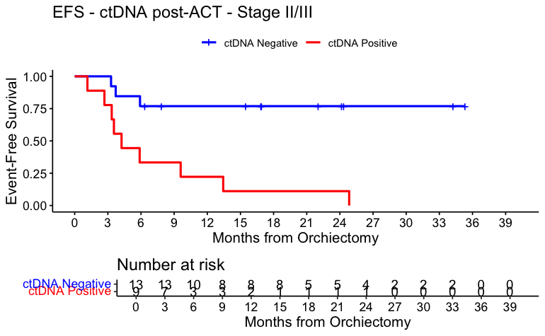

```r
surv_object <-Surv(time = circ_data$PFS.months, event = circ_data$PFS.Event)
KM_curve <- survfit(surv_object ~ ctDNA.surveillance, data = circ_data,conf.int=0.95,conf.type="log-log")
ggsurvplot(KM_curve, data = circ_data, pval = FALSE, conf.int = FALSE, risk.table = TRUE, break.time.by=3, palette=c("blue","red"), title="EFS - ctDNA post-ACT - Stage II/III", ylab= "Event-Free Survival", xlab="Months from Orchiectomy", legend.labs=c("ctDNA Negative", "ctDNA Positive"), legend.title="")
```

```r
summary(KM_curve, times= c(12, 24))
```

```
Call: survfit(formula = surv_object ~ ctDNA.surveillance, data = circ_data,
    conf.int = 0.95, conf.type = "log-log")

                ctDNA.surveillance=NEGATIVE
 time n.risk n.event survival std.err lower 95% CI upper 95% CI
   12      8       3    0.769   0.117        0.442        0.919
   24      4       0    0.769   0.117        0.442        0.919

                ctDNA.surveillance=POSITIVE
 time n.risk n.event survival std.err lower 95% CI upper 95% CI
   12      2       7    0.222   0.139      0.03371        0.513
   24      1       1    0.111   0.105      0.00613        0.388
```

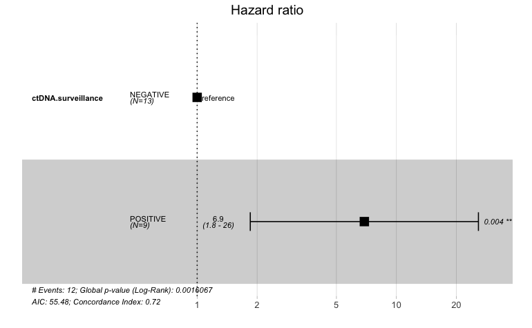

```r
circ_data$ctDNA.surveillance <- factor(circ_data$ctDNA.surveillance, levels=c("NEGATIVE","POSITIVE"))
cox_fit <- coxph(surv_object ~ ctDNA.surveillance, data=circ_data)
ggforest(cox_fit,data = circ_data)
```

```r
summary(cox_fit)
```

```
Call:
coxph(formula = surv_object ~ ctDNA.surveillance, data = circ_data)

  n= 22, number of events= 12

                             coef exp(coef) se(coef)     z Pr(>|z|)
ctDNA.surveillancePOSITIVE 1.9323    6.9055   0.6727 2.873  0.00407 **
---
Signif. codes:  0 ‘***’ 0.001 ‘**’ 0.01 ‘*’ 0.05 ‘.’ 0.1 ‘ ’ 1

                           exp(coef) exp(-coef) lower .95 upper .95
ctDNA.surveillancePOSITIVE     6.905     0.1448     1.848     25.81

Concordance= 0.716  (se = 0.067 )
Likelihood ratio test= 9.95  on 1 df,   p=0.002
Wald test            = 8.25  on 1 df,   p=0.004
Score (logrank) test = 10.97  on 1 df,   p=9e-04
```

```r
cox_fit_summary <- summary(cox_fit)

# Extract values for HR, 95% CI, and p-value
HR <- cox_fit_summary$coefficients[2]
lower_CI <- cox_fit_summary$conf.int[3]
upper_CI <- cox_fit_summary$conf.int[4]
p_value <- cox_fit_summary$coefficients[5]
label_text <- paste0("HR = ", round(HR, 2), " (", round(lower_CI, 2), "-", round(upper_CI, 2), "); p = ", round(p_value, 3))
print(label_text)
```

```
[1] "HR = 6.91 (1.85-25.81); p = 0.004"
```

#EFS by STMs at post-ACT - Stage II/III

```r
rm(list=ls())
setwd("~/Downloads")
circ_data <- read.csv("CLIA Testicular_GL.csv")
circ_data <- circ_data[circ_data$ctDNA.available==TRUE,]
circ_data <- circ_data[circ_data$ACT==TRUE,]
circ_data <- circ_data[circ_data$Stage!="I",]
circ_data <- circ_data[circ_data$Markers.Surveillance!="",]
circ_datadf <- as.data.frame(circ_data)

survfit(Surv(time = circ_data$PFS.months, event = circ_data$PFS.Event)~Markers.Surveillance, data = circ_data)
```

```
Call: survfit(formula = Surv(time = circ_data$PFS.months, event = circ_data$PFS.Event) ~
    Markers.Surveillance, data = circ_data)

                               n events median 0.95LCL 0.95UCL
Markers.Surveillance=NEGATIVE 23     11   65.3    7.69      NA
Markers.Surveillance=POSITIVE 10      8   20.0    5.59      NA
```

```r
event_summary <- circ_data %>%
  group_by(Markers.Surveillance) %>%
  summarise(
    Total = n(),
    Events = sum(PFS.Event),
    Fraction = Events / n(),
    Percentage = (Events / n()) * 100
  )
print(event_summary)
```

| Markers.Surveillance | Total | Events | Fraction | Percentage |
| --- | --- | --- | --- | --- |
| NEGATIVE | 23 | 11 | 0.4782609 | 47.82609 |
| POSITIVE | 10 | 8 | 0.8000000 | 80.00000 |

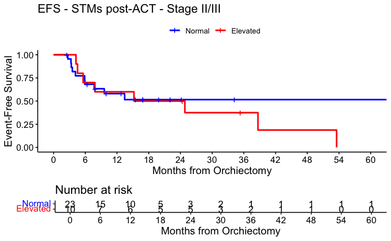

```r
surv_object <-Surv(time = circ_data$PFS.months, event = circ_data$PFS.Event)
KM_curve <- survfit(surv_object ~ Markers.Surveillance, data = circ_data,conf.int=0.95,conf.type="log-log")
ggsurvplot(KM_curve, data = circ_data, pval = FALSE, conf.int = FALSE, risk.table = TRUE, break.time.by=6, palette=c("blue","red"), title="EFS - STMs post-ACT - Stage II/III", ylab= "Event-Free Survival", xlab="Months from Orchiectomy", legend.labs=c("Normal", "Elevated"), legend.title="")
```

```r
summary(KM_curve, times= c(12, 24))
```

```
Call: survfit(formula = surv_object ~ Markers.Surveillance, data = circ_data,
    conf.int = 0.95, conf.type = "log-log")

                Markers.Surveillance=NEGATIVE
 time n.risk n.event survival std.err lower 95% CI upper 95% CI
   12     10       9    0.580   0.107        0.346        0.756
   24      3       1    0.516   0.113        0.281        0.708

                Markers.Surveillance=POSITIVE
 time n.risk n.event survival std.err lower 95% CI upper 95% CI
   12      6       4      0.6   0.155        0.253        0.827
   24      5       1      0.5   0.158        0.184        0.753
```

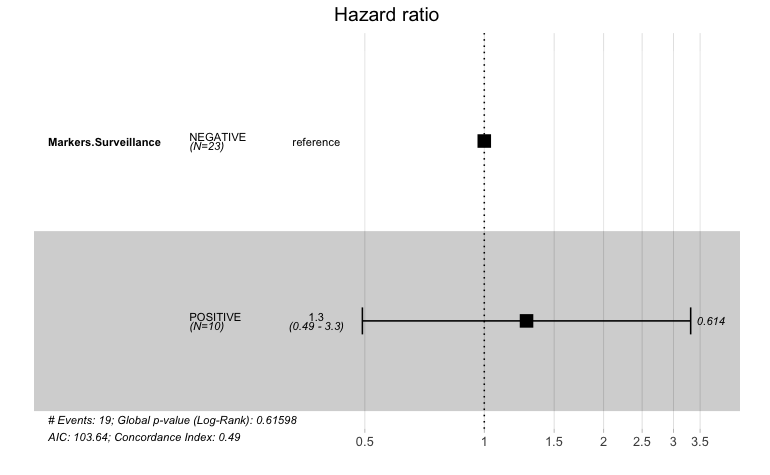

```r
circ_data$Markers.Surveillance <- factor(circ_data$Markers.Surveillance, levels=c("NEGATIVE","POSITIVE"))
cox_fit <- coxph(surv_object ~ Markers.Surveillance, data=circ_data)
ggforest(cox_fit,data = circ_data)
```

```r
summary(cox_fit)
```

```
Call:
coxph(formula = surv_object ~ Markers.Surveillance, data = circ_data)

  n= 33, number of events= 19

                               coef exp(coef) se(coef)     z Pr(>|z|)
Markers.SurveillancePOSITIVE 0.2453    1.2780   0.4862 0.505    0.614

                             exp(coef) exp(-coef) lower .95 upper .95
Markers.SurveillancePOSITIVE     1.278     0.7825    0.4928     3.314

Concordance= 0.49  (se = 0.058 )
Likelihood ratio test= 0.25  on 1 df,   p=0.6
Wald test            = 0.25  on 1 df,   p=0.6
Score (logrank) test = 0.26  on 1 df,   p=0.6
```

```r
cox_fit_summary <- summary(cox_fit)

# Extract values for HR, 95% CI, and p-value
HR <- cox_fit_summary$coefficients[2]
lower_CI <- cox_fit_summary$conf.int[3]
upper_CI <- cox_fit_summary$conf.int[4]
p_value <- cox_fit_summary$coefficients[5]
label_text <- paste0("HR = ", round(HR, 2), " (", round(lower_CI, 2), "-", round(upper_CI, 2), "); p = ", round(p_value, 3))
print(label_text)
```

```
[1] "HR = 1.28 (0.49-3.31); p = 0.614"
```